# GoodCardio-MaryamShokoufi

## Problem Statement and Data Dictionary

The data is about customers of the treadmill product(s) of a retail store called Cardio Good Fitness. It contains the following variables Product - The model no. of the treadmill Age - Age of the customer in no of years Gender - Gender of the customer Education - Education of the customer in no. of years Marital Status - Marital status of the customer Usage - Avg. # times the customer wants to use the treadmill every week Fitness - Self rated fitness score of the customer (5 - very fit, 1 - very unfit) Income - Income of the customer Miles- Miles that a customer expects to run

## 1. Import the necessary packages

```python
import pandas as pd
import numpy as np
import seaborn as sns
import matplotlib.pyplot as plt
sns.set(color_codes=True)
%matplotlib inline
import warnings
warnings.filterwarnings("ignore")
from PIL import Image
```

## 2. Read the dataset

```python
data = pd.read_csv("CardioGoodFitness.csv")
```

## 3. View the first 5 rows of the dataset

```python
data.head(5)
```

|  | Product | Age | Gender | Education | MaritalStatus | Usage | Fitness | Income | Miles |
| --- | --- | --- | --- | --- | --- | --- | --- | --- | --- |
| 0 | TM195 | 18 | Male | 14 | Single | 3 | 4 | 29562 | 112 |
| 1 | TM195 | 19 | Male | 15 | Single | 2 | 3 | 31836 | 75 |
| 2 | TM195 | 19 | Female | 14 | Partnered | 4 | 3 | 30699 | 66 |
| 3 | TM195 | 19 | Male | 12 | Single | 3 | 3 | 32973 | 85 |
| 4 | TM195 | 20 | Male | 13 | Partnered | 4 | 2 | 35247 | 47 |

## 4. Understand the shape of the dataset

```python
data.shape
```

```
(180, 9)
```

**Observation:** There are 180 rows and 9 columns in our cardio dataset that we named data

## 5. Check the data types of the columns

```python
data.dtypes
```

```
Product          object
Age               int64
Gender           object
Education         int64
MaritalStatus    object
Usage             int64
Fitness           int64
Income            int64
Miles             int64
dtype: object
```

**Observations**: Age, Education, Usage, Fitness, Income and Miles columns are of integer data types Product, Gender and MaritalStatus columns are of string data type.

## 6. Check for null data

```python
data.isnull().sum()
```

```
Product          0
Age              0
Gender           0
Education        0
MaritalStatus    0
Usage            0
Fitness          0
Income           0
Miles            0
dtype: int64
```

**Observation:** There are no null values

## 7.1 Give a statistical summary for all the datasets.

```python
data.describe()
```

|  | Age | Education | Usage | Fitness | Income | Miles |
| --- | --- | --- | --- | --- | --- | --- |
| count | 180.000000 | 180.000000 | 180.000000 | 180.000000 | 180.000000 | 180.000000 |
| mean | 28.788889 | 15.572222 | 3.455556 | 3.311111 | 53719.577778 | 103.194444 |
| std | 6.943498 | 1.617055 | 1.084797 | 0.958869 | 16506.684226 | 51.863605 |
| min | 18.000000 | 12.000000 | 2.000000 | 1.000000 | 29562.000000 | 21.000000 |
| 25% | 24.000000 | 14.000000 | 3.000000 | 3.000000 | 44058.750000 | 66.000000 |
| 50% | 26.000000 | 16.000000 | 3.000000 | 3.000000 | 50596.500000 | 94.000000 |
| 75% | 33.000000 | 16.000000 | 4.000000 | 4.000000 | 58668.000000 | 114.750000 |
| max | 50.000000 | 21.000000 | 7.000000 | 5.000000 | 104581.000000 | 360.000000 |

```python
data.skew()
```

```
Age          0.982161
Education    0.622294
Usage        0.739494
Fitness      0.454800
Income       1.291785
Miles        1.724497
dtype: float64
```

## 7.2DataType Conversions

To better be able to analize the data, we can convert the Gender and MaritalStatus features to binary, and also assign a code(1,2,3) to Product types. Also we can create a dataframe for each product to better understand the customer profile of each individually.

```python
numerical_data=data.copy()
numerical_data['Gender'].replace(to_replace=['Male', 'Female'], value=[0, 1], inplace=True)
numerical_data['MaritalStatus'].replace(to_replace=['Single', 'Partnered'], value=[0, 1], inplace=True)
numerical_data['Product'].replace(to_replace=['TM195', 'TM498', 'TM798'], value=[1, 2, 3], inplace=True)

product1_data=numerical_data[numerical_data['Product']==1]
product2_data=numerical_data[numerical_data['Product']==2]
product3_data=numerical_data[numerical_data['Product']==3]
```

```python
product1_data.describe()
```

|  | Product | Age | Gender | Education | MaritalStatus | Usage | Fitness | Income | Miles |
| --- | --- | --- | --- | --- | --- | --- | --- | --- | --- |
| count | 80.0 | 80.000000 | 80.000000 | 80.000000 | 80.000000 | 80.000000 | 80.00000 | 80.00000 | 80.000000 |
| mean | 1.0 | 28.550000 | 0.500000 | 15.037500 | 0.600000 | 3.087500 | 2.96250 | 46418.02500 | 82.787500 |
| std | 0.0 | 7.221452 | 0.503155 | 1.216383 | 0.492989 | 0.782624 | 0.66454 | 9075.78319 | 28.874102 |
| min | 1.0 | 18.000000 | 0.000000 | 12.000000 | 0.000000 | 2.000000 | 1.00000 | 29562.00000 | 38.000000 |
| 25% | 1.0 | 23.000000 | 0.000000 | 14.000000 | 0.000000 | 3.000000 | 3.00000 | 38658.00000 | 66.000000 |
| 50% | 1.0 | 26.000000 | 0.500000 | 16.000000 | 1.000000 | 3.000000 | 3.00000 | 46617.00000 | 85.000000 |
| 75% | 1.0 | 33.000000 | 1.000000 | 16.000000 | 1.000000 | 4.000000 | 3.00000 | 53439.00000 | 94.000000 |
| max | 1.0 | 50.000000 | 1.000000 | 18.000000 | 1.000000 | 5.000000 | 5.00000 | 68220.00000 | 188.000000 |

Customers with product TM195 have : average age of 28, about the same number of each gender, college degree on average, average usage of about 3 days per week, average income of 46418 and want to run average of 82 miles

```python
product2_data.describe()
```

|  | Product | Age | Gender | Education | MaritalStatus | Usage | Fitness | Income | Miles |
| --- | --- | --- | --- | --- | --- | --- | --- | --- | --- |
| count | 60.0 | 60.000000 | 60.000000 | 60.000000 | 60.000000 | 60.000000 | 60.00000 | 60.000000 | 60.000000 |
| mean | 2.0 | 28.900000 | 0.483333 | 15.116667 | 0.600000 | 3.066667 | 2.90000 | 48973.650000 | 87.933333 |
| std | 0.0 | 6.645248 | 0.503939 | 1.222552 | 0.494032 | 0.799717 | 0.62977 | 8653.989388 | 33.263135 |
| min | 2.0 | 19.000000 | 0.000000 | 12.000000 | 0.000000 | 2.000000 | 1.00000 | 31836.000000 | 21.000000 |
| 25% | 2.0 | 24.000000 | 0.000000 | 14.000000 | 0.000000 | 3.000000 | 3.00000 | 44911.500000 | 64.000000 |
| 50% | 2.0 | 26.000000 | 0.000000 | 16.000000 | 1.000000 | 3.000000 | 3.00000 | 49459.500000 | 85.000000 |
| 75% | 2.0 | 33.250000 | 1.000000 | 16.000000 | 1.000000 | 3.250000 | 3.00000 | 53439.000000 | 106.000000 |
| max | 2.0 | 48.000000 | 1.000000 | 18.000000 | 1.000000 | 5.000000 | 4.00000 | 67083.000000 | 212.000000 |

```python
product3_data.describe()
```

|  | Product | Age | Gender | Education | MaritalStatus | Usage | Fitness | Income | Miles |
| --- | --- | --- | --- | --- | --- | --- | --- | --- | --- |
| count | 40.0 | 40.000000 | 40.000000 | 40.000000 | 40.000000 | 40.000000 | 40.000000 | 40.00000 | 40.000000 |
| mean | 3.0 | 29.100000 | 0.175000 | 17.325000 | 0.575000 | 4.775000 | 4.625000 | 75441.57500 | 166.900000 |
| std | 0.0 | 6.971738 | 0.384808 | 1.639066 | 0.500641 | 0.946993 | 0.667467 | 18505.83672 | 60.066544 |
| min | 3.0 | 22.000000 | 0.000000 | 14.000000 | 0.000000 | 3.000000 | 3.000000 | 48556.00000 | 80.000000 |
| 25% | 3.0 | 24.750000 | 0.000000 | 16.000000 | 0.000000 | 4.000000 | 4.000000 | 58204.75000 | 120.000000 |
| 50% | 3.0 | 27.000000 | 0.000000 | 18.000000 | 1.000000 | 5.000000 | 5.000000 | 76568.50000 | 160.000000 |
| 75% | 3.0 | 30.250000 | 0.000000 | 18.000000 | 1.000000 | 5.000000 | 5.000000 | 90886.00000 | 200.000000 |
| max | 3.0 | 48.000000 | 1.000000 | 21.000000 | 1.000000 | 7.000000 | 5.000000 | 104581.00000 | 360.000000 |

## 7.2. Compare average customer profiles across Products

To better visualize how customer profiles are different for each product, we can look at the mean values for each of the features and compare them across products as shown below:

```python
Average_data_1= product1_data.describe().loc['mean']
Average_data_2= product2_data.describe().loc['mean']
Average_data_3= product3_data.describe().loc['mean']
Average_data = pd.concat([Average_data_1,Average_data_2,Average_data_3],axis=1, keys=['MT195', 'MT498', 'MT798'])
Average_data = Average_data.T
Average_data
```

|  | Product | Age | Gender | Education | MaritalStatus | Usage | Fitness | Income | Miles |
| --- | --- | --- | --- | --- | --- | --- | --- | --- | --- |
| MT195 | 1.0 | 28.55 | 0.500000 | 15.037500 | 0.600 | 3.087500 | 2.9625 | 46418.025 | 82.787500 |
| MT498 | 2.0 | 28.90 | 0.483333 | 15.116667 | 0.600 | 3.066667 | 2.9000 | 48973.650 | 87.933333 |
| MT798 | 3.0 | 29.10 | 0.175000 | 17.325000 | 0.575 | 4.775000 | 4.6250 | 75441.575 | 166.900000 |

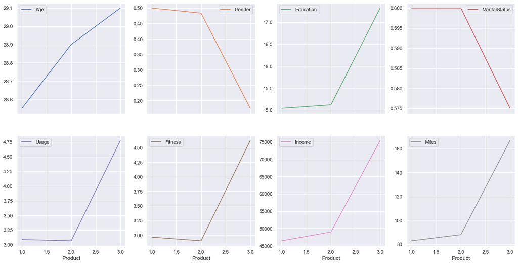

```python
Average_data.plot(x= 'Product', layout=(2,4),subplots=True, figsize=(20,10))
plt.show()
```

## 8.Univariate Analysis

### 8.1. Number of units sold per product:

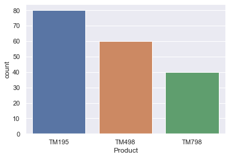

```python
sns.countplot(data['Product']);
```

```python
data['Product'].value_counts()
```

```
TM195    80
TM498    60
TM798    40
Name: Product, dtype: int64
```

*Observation: 80 customers bought TM195, 60 bought TM498 and 40 customers bought TM798

### 8.2 Customer breakdown by Age:

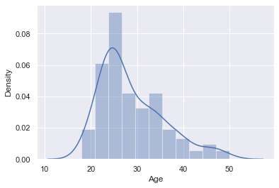

```python
sns.distplot(data['Age']);
```

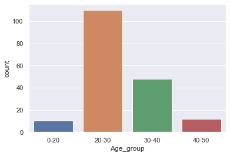

```python
data['Age_group']=pd.cut(data.Age, bins=(0,20,30,40,50),labels=('0-20','20-30','30-40','40-50'))
sns.countplot(data['Age_group']);
```

*Observation: We can see that most of the customers are from age group of 20-30 year olds. We will need to see if that is true on all products.

### 8.3. Customer breakdown by gender:

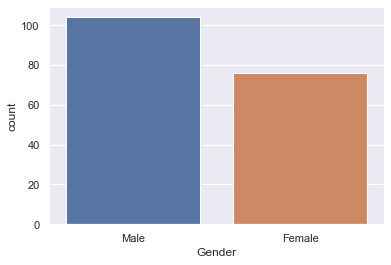

```python
sns.countplot(data['Gender']);
```

```python
data['Gender'].value_counts()
```

```
Male      104
Female     76
Name: Gender, dtype: int64
```

*Observation: Less female customers than male in total. We can analize this further across different products to understand which one is more/less appealing to each gender.

### 8.4 Distribution of customers by their education level:

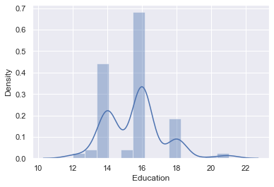

```python
sns.distplot(data['Education']);
```

```
College         150
Graduate         24
HighSchool        3
PostGraduate      3
Name: Education_group, dtype: int64
```

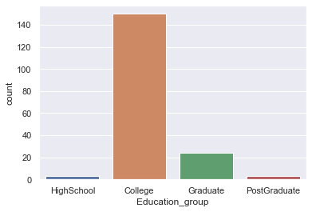

```python
data['Education_group']=pd.cut(data.Education, bins=(0,12,16,20,25),
                               labels=('HighSchool','College','Graduate','PostGraduate'))
sns.countplot(data = data, x='Education_group');
data['Education_group'].value_counts()
```

### 8.5. Breakdown of customers by their MaritalStatus:

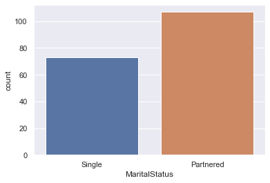

```python
sns.countplot(data['MaritalStatus']);
```

```python
data['MaritalStatus'].value_counts()
```

```
Partnered    107
Single        73
Name: MaritalStatus, dtype: int64
```

**Observation**: Most customers are partnered.

### 8.6. Distribution of Expected Usage

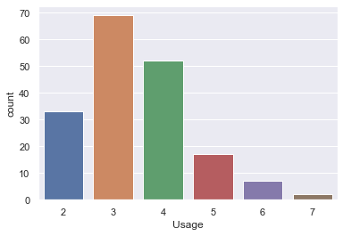

```python
sns.countplot(data['Usage']);
```

### 8.6. Distribution of Customer Fitness

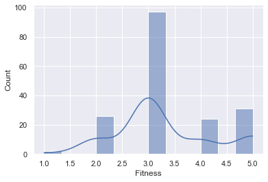

```python
sns.histplot(data['Fitness'], kde=True);
```

```python
data['Fitness'].value_counts()
```

```
3    97
5    31
2    26
4    24
1     2
Name: Fitness, dtype: int64
```

**Observation**: Looks like most of the customers rate themselves as 3 or above on a scale of 1 to 5. That means that most of the customers are in good shape, which is not the expected target group for treadmills. The company may want to expand the products and target less fit customers.

### 8.3 Distribution of customer Income

```python
data['Income'].agg(['mean','median','std'])
```

```
mean      53719.577778
median    50596.500000
std       16506.684226
Name: Income, dtype: float64
```

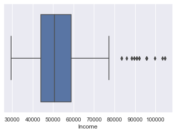

```python
sns.boxplot(data['Income']);
```

```python
income_outliers=data[data['Income']>75000]
income_outliers['Product'].value_counts()
```

```
TM798    21
Name: Product, dtype: int64
```

**Observation**: We can see that all the outliers are customers that have product TM798.

### 8.6. Distribution of Miles expected to run by a customer

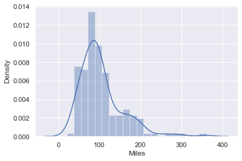

```python
sns.distplot(data['Miles']);
```

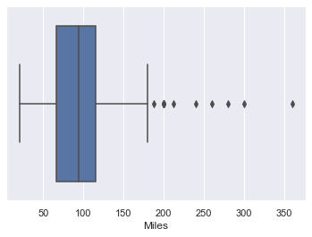

```python
sns.boxplot(data['Miles']);
```

```python
miles_outliers = data[data['Miles']>175]
miles_outliers['Product'].value_counts()
```

```
TM798    17
TM195     1
TM498     1
Name: Product, dtype: int64
```

**Observation**: Customers expect to run 103.1 miles on average, with median of 94 and range is from 21 to 360. Again we can see that 17 out of 19 outliers are customers that have product TM798.

## 9.Multivariate Analysis

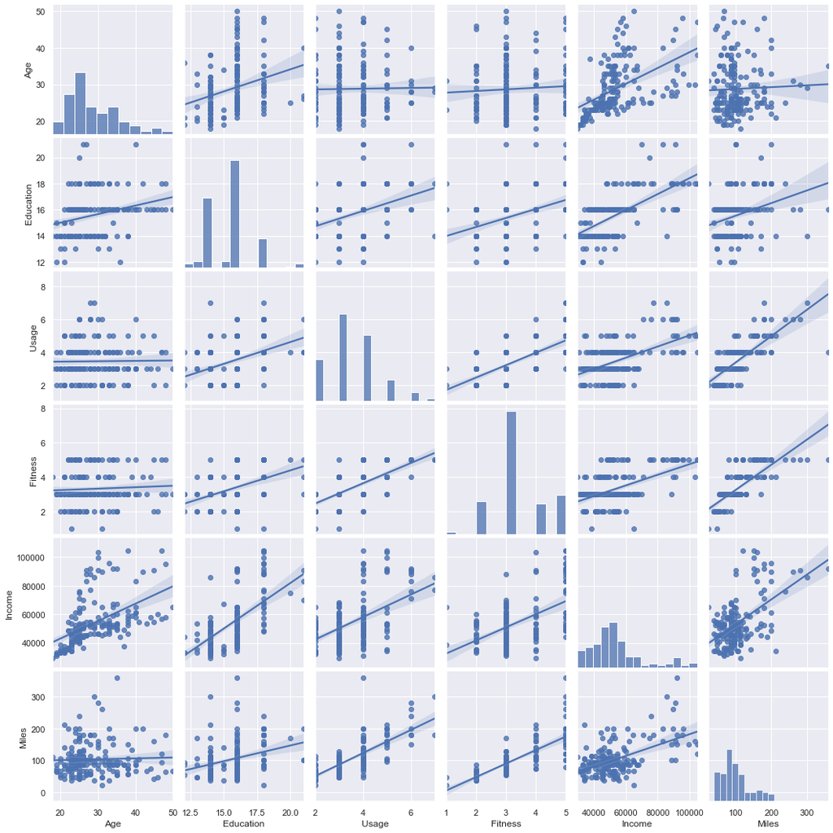

```python
sns.pairplot(data, kind='reg')
plt.show()
```

```python
correlation = numerical_data.corr() # creating a 2-D Matrix with correlation plots
correlation
```

|  | Product | Age | Gender | Education | MaritalStatus | Usage | Fitness | Income | Miles |
| --- | --- | --- | --- | --- | --- | --- | --- | --- | --- |
| Product | 1.000000 | 0.032225 | -0.230653 | 0.495018 | -0.017602 | 0.537447 | 0.594883 | 0.624168 | 0.571596 |
| Age | 0.032225 | 1.000000 | -0.027544 | 0.280496 | 0.192152 | 0.015064 | 0.061105 | 0.513414 | 0.036618 |
| Gender | -0.230653 | -0.027544 | 1.000000 | -0.094089 | 0.018836 | -0.214424 | -0.254609 | -0.202053 | -0.217869 |
| Education | 0.495018 | 0.280496 | -0.094089 | 1.000000 | 0.068569 | 0.395155 | 0.410581 | 0.625827 | 0.307284 |
| MaritalStatus | -0.017602 | 0.192152 | 0.018836 | 0.068569 | 1.000000 | -0.007786 | -0.050751 | 0.150293 | 0.025639 |
| Usage | 0.537447 | 0.015064 | -0.214424 | 0.395155 | -0.007786 | 1.000000 | 0.668606 | 0.519537 | 0.759130 |
| Fitness | 0.594883 | 0.061105 | -0.254609 | 0.410581 | -0.050751 | 0.668606 | 1.000000 | 0.535005 | 0.785702 |
| Income | 0.624168 | 0.513414 | -0.202053 | 0.625827 | 0.150293 | 0.519537 | 0.535005 | 1.000000 | 0.543473 |
| Miles | 0.571596 | 0.036618 | -0.217869 | 0.307284 | 0.025639 | 0.759130 | 0.785702 | 0.543473 | 1.000000 |

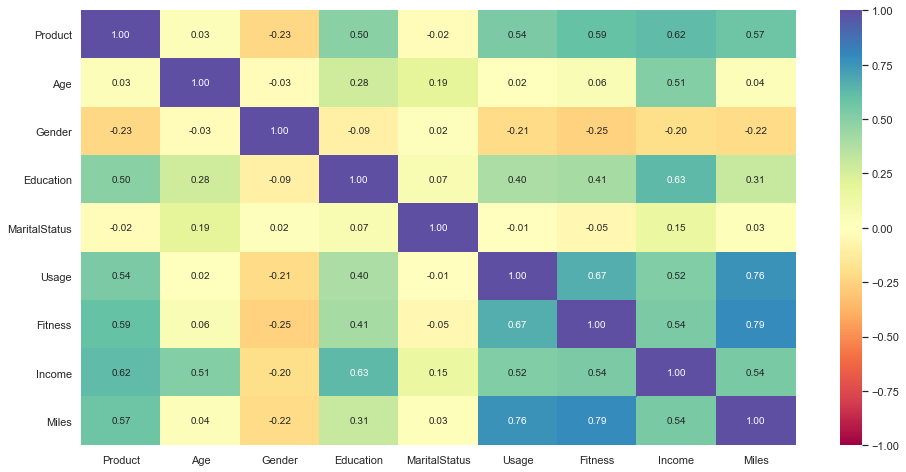

```python
plt.figure(figsize=(16, 8))
sns.heatmap(correlation, annot=True, vmin=-1, vmax=1, fmt=".2f", cmap="Spectral")
plt.show()
```

**Observation**: Type of the Product is correlated most strongly to Income, then Fitness, Miles, Usage and Education. Miles is strongly correlated with Usage and Fitness at 0.76 and 0.79 which is expected. Income is correlated with Education at 0.63, also slightly correlated with Age at 0.51, Usage at 0.52 and with Miles and Fitness at 0.54. It is surprising to see that Fitness and Age are not inversely correlated at 0.06. There seems to be an inverse correlation between Gender and Usage, Fitness, Income and Miles. It also shows Females tend to buy first two products more than the third(TM798). MaritalStatus seems to not correlate or affect any other feature. We will investigate these results to form more insight and conclusion.